## Project 2 - Data Set 1

#### By Brian Weinfeld

##### March 3rd, 2018

### World Populations

For my first data set, I selected the world populations csv file discussed by Steven. The file contains a large number of countries and their populations in millions for each year from 1980 through 2010.

```r
raw.data <- read_csv('C:\\Users\\Brian\\Desktop\\GradClasses\\Spring18\\migrantdata\\populationbycountry19802010millions.csv',
                     na=c('NA'))
kable(raw.data[, 1:5] %>% head())
```

| X1 | 1980 | 1981 | 1982 | 1983 |
| --- | --- | --- | --- | --- |
| North America | 320.27638 | 324.44694 | 328.62014 | 332.72487 |
| Bermuda | 0.05473 | 0.05491 | 0.05517 | 0.05551 |
| Canada | 24.5933 | 24.9 | 25.2019 | 25.4563 |
| Greenland | 0.05021 | 0.05103 | 0.05166 | 0.05211 |
| Mexico | 68.34748 | 69.96926 | 71.6409 | 73.36288 |
| Saint Pierre and Miquelon | 0.00599 | 0.00601 | 0.00605 | 0.00607 |

In order to make the data tidy I gathered all the year columns and put them in a single column and then arranged the data alphabetically by country. Finally, I wrote the file out for future use.

```r
raw.data %<>%
  rename(country=X1) %>%
  gather(year, population, 2:32) %>%
  arrange(country) %T>%
  write.csv('C:\\Users\\Brian\\Desktop\\GradClasses\\Spring18\\migrantdata\\population_answer.csv')
kable(raw.data %>% head())
```

| country | year | population |
| --- | --- | --- |
| Afghanistan | 1980 | 15.0436 |
| Afghanistan | 1981 | 13.67368 |
| Afghanistan | 1982 | 12.57743 |
| Afghanistan | 1983 | 12.43058 |
| Afghanistan | 1984 | 12.75384 |
| Afghanistan | 1985 | 13.09371 |

Working off of Steven’s suggestion about the prevelance of missing data, I decided to highlight the countries with the most missing data. I created a subset that contained all the missing data in the original raw data and read in another csv file I found online that contained a list of countries and their longitude and latitude.

```r
missing.data <- raw.data %>%
  subset(population == '--' | is.na(population))

country.locations <- read.csv('C:\\Users\\Brian\\Desktop\\GradClasses\\Spring18\\migrantdata\\country_locations.csv', stringsAsFactors=FALSE)
kable(country.locations %>% head())
```

| country | latitude | longitude | name |
| --- | --- | --- | --- |
| AD | 42.54624 | 1.601554 | Andorra |
| AE | 23.42408 | 53.847818 | United Arab Emirates |
| AF | 33.93911 | 67.709953 | Afghanistan |
| AG | 17.06082 | -61.796428 | Antigua and Barbuda |
| AI | 18.22055 | -63.068615 | Anguilla |
| AL | 41.15333 | 20.168331 | Albania |

I created data to plot by counting the number of missing entries and joining that information with the country locations. I created another column to dictate the size of the circles on the plot named mod.pop.

```r
plotting.data <- missing.data %>%
  count(country, population) %>%
  inner_join(country.locations, by=c('country'='name')) %>%
  mutate(mod.pop = sigmoid((n / max(n)))*5)
kable(plotting.data %>% head())
```

| country | population | n | country.y | latitude | longitude | mod.pop |
| --- | --- | --- | --- | --- | --- | --- |
| Antarctica | NA | 31 | AQ | -75.25097 | -0.071389 | 3.655293 |
| Armenia | – | 12 | AM | 40.06910 | 45.038189 | 2.977918 |
| Aruba | – | 6 | AW | 12.52111 | -69.968338 | 2.741183 |
| Azerbaijan | – | 12 | AZ | 40.14310 | 47.576927 | 2.977918 |
| Belarus | – | 12 | BY | 53.70981 | 27.953389 | 2.977918 |
| Bosnia and Herzegovina | – | 12 | BA | 43.91589 | 17.679076 | 2.977918 |

Finally, I plotted the data. I used hollow cirlces for NA data and solid circles for missing (dash-dash) data.

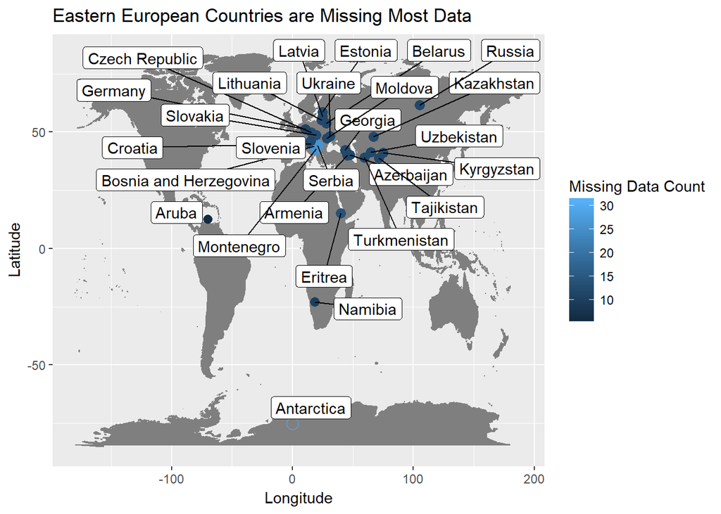

```r
ggplot(plotting.data) +
  borders('world', color='gray50', fill='gray50') +
  geom_point(aes(x=longitude, y=latitude, color=n),
             shape=ifelse(is.na(plotting.data$population), 21, 16),
             size = plotting.data$mod.pop
             ) +
  geom_label_repel(aes(x=longitude, y=latitude, label=country)) +
  labs(x='Longitude',
     y='Latitude',
     color='Missing Data Count',
     title='Eastern European Countries are Missing Most Data'
  )
```

The graph shows that most of the missing data comes from eastern Europe. It should be noted that some missing elements were removed by the inner join on country locations as those countries were not part of the data set. The most common reason is that the countries no longger exist. For example, ‘Former USSR’ was listed as a country in the original data set.’